# Oil Trading Game

FE8828 AY20/21 Demo

Yang Ye

```r
library(conflicted)
library(tidyverse)
library(lubridate)
library(Quandl)
library(xts)
library(forecast)
```

```r
library(dygraphs)
library(testit)
library(kableExtra)
conflict_prefer('last', 'dplyr')
```

```
## [conflicted] Will prefer dplyr::last over any other package
```

```r
conflict_prefer('lag', 'dplyr')
```

```
## [conflicted] Will prefer dplyr::lag over any other package
```

```r
conflict_prefer('filter', 'dplyr')
```

```
## [conflicted] Will prefer dplyr::filter over any other package
```

```r
options(dplyr.summarise.inform = FALSE)
```

# Oil Trading Game

- WTI Crude Oil https://fred.stlouisfed.org/series/DCOILWTICO
- Price history: 2006-01-01 to 2020-10-05
- Daily price predication. Once started, have either long or short every day.
- Idea: Time series prediction. We assume a linear relationship between past returns to next return.
  $$\textit{Ret}_{n+1} = \sum_{i=0}^{n} {w_{i} \textit{Ret}_{i}}$$
- Regression and classification are two main categories of machine learning algorithms under supervised learning.
- We use regression to calculate the weights.
- Disclaimer: This is not an investment advice. There are many assumptions made in this code for the data. Not all prices are tradable.

## Download Price

```r
# It seems find to leave token_qd as empty string. Subject to Quandl package.
# Setup Quandl
token_qd <- ''
Quandl.api_key(token_qd)

# Start with daily data. Note that "type = raw" will download a data frame.
oil_daily <- Quandl("FRED/DCOILWTICO", type = "raw", collapse = "daily",
                    start_date="2006-01-01", end_date="2020-10-05")
head(oil_daily)
```

|  | Date | Value |
| --- | --- | --- |
| 1 | 2020-10-05 | 39.12 |
| 2 | 2020-10-02 | 36.90 |
| 3 | 2020-10-01 | 38.51 |
| 4 | 2020-09-30 | 40.05 |
| 5 | 2020-09-29 | 39.03 |
| 6 | 2020-09-28 | 40.47 |

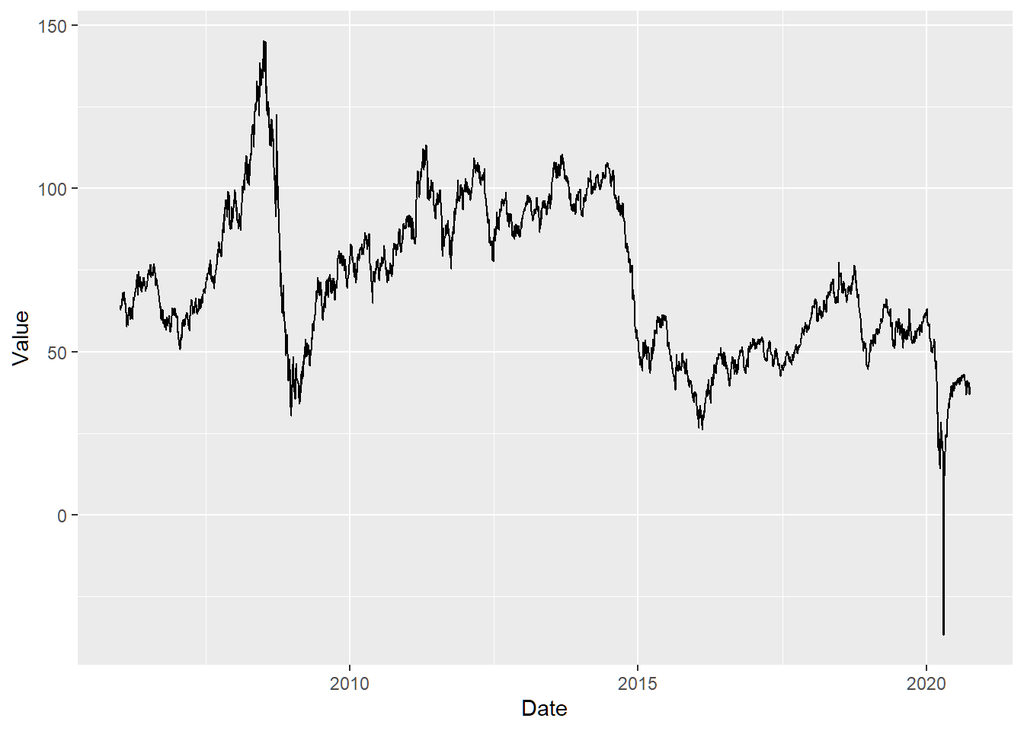

```r
ggplot(oil_daily) + geom_line(aes(Date, Value))
```

## Autocorrelation function (ACF)

### ACF on Price

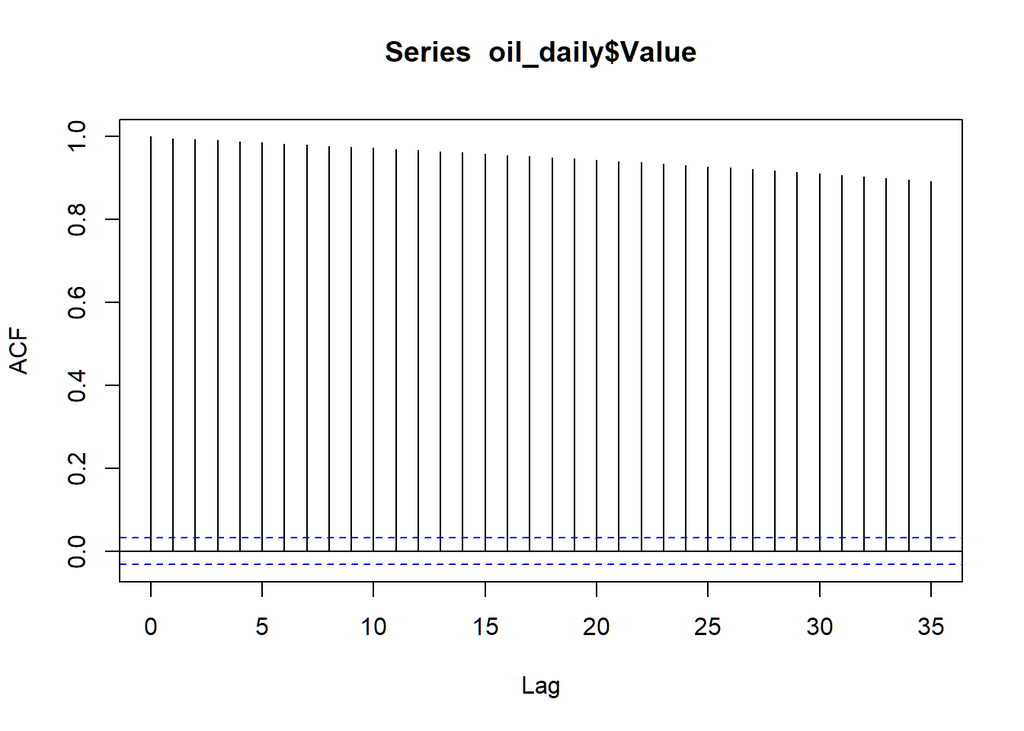

```r
oil_daily_original <- oil_daily
acf(oil_daily$Value)
```

### ACF on Return

```r
oil_daily_ret <- oil_daily %>% mutate(ret = Value / lead(Value, 1) - 1 ) %>% head(-1)
head(oil_daily_ret)
```

|  | Date | Value | ret |
| --- | --- | --- | --- |
| 1 | 2020-10-05 | 39.12 | 0.06016260 |
| 2 | 2020-10-02 | 36.90 | -0.04180732 |
| 3 | 2020-10-01 | 38.51 | -0.03845194 |
| 4 | 2020-09-30 | 40.05 | 0.02613374 |
| 5 | 2020-09-29 | 39.03 | -0.03558191 |
| 6 | 2020-09-28 | 40.47 | 0.01023465 |

```r
tail(oil_daily_ret)
```

|  | Date | Value | ret |
| --- | --- | --- | --- |
| 3705 | 2006-01-11 | 63.91 | 0.007885192 |
| 3706 | 2006-01-10 | 63.41 | -0.002359975 |
| 3707 | 2006-01-09 | 63.56 | -0.010123034 |
| 3708 | 2006-01-06 | 64.21 | 0.022289444 |
| 3709 | 2006-01-05 | 62.81 | -0.009462230 |
| 3710 | 2006-01-04 | 63.41 | 0.004753605 |

```r
tail(oil_daily)
```

|  | Date | Value |
| --- | --- | --- |
| 3706 | 2006-01-10 | 63.41 |
| 3707 | 2006-01-09 | 63.56 |
| 3708 | 2006-01-06 | 64.21 |
| 3709 | 2006-01-05 | 62.81 |
| 3710 | 2006-01-04 | 63.41 |
| 3711 | 2006-01-03 | 63.11 |

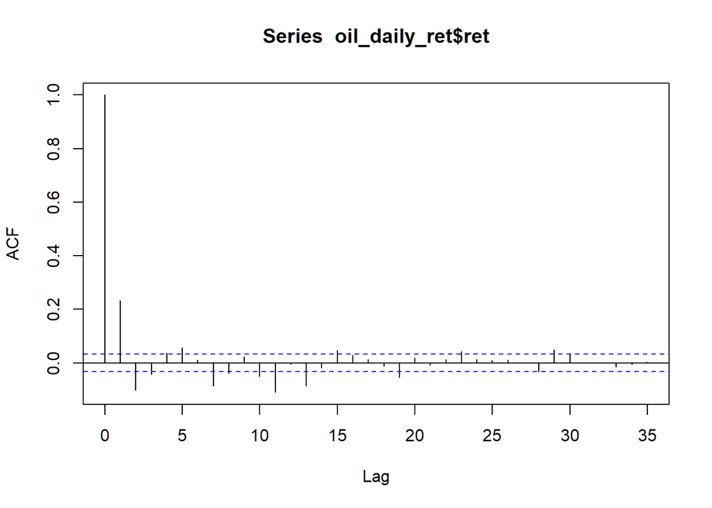

```r
acf_result <- acf(oil_daily_ret$ret)
```

### Use ACF to identify significant past returns

```r
# The return value from acf function is a list, containing the data.
acf_result
```

```
##
## Autocorrelations of series 'oil_daily_ret$ret', by lag
##
##      0      1      2      3      4      5      6      7      8      9     10
##  1.000  0.232 -0.102 -0.041  0.037  0.056  0.012 -0.086 -0.039  0.023 -0.050
##     11     12     13     14     15     16     17     18     19     20     21
## -0.110 -0.005 -0.087 -0.019  0.046  0.028  0.013 -0.013 -0.054  0.020 -0.009
##     22     23     24     25     26     27     28     29     30     31     32
##  0.013  0.042  0.014  0.008  0.010  0.000 -0.032  0.048  0.034  0.002 -0.001
##     33     34     35
## -0.015 -0.006  0.004
```

```r
str(acf_result)
```

```
## List of 6
##  $ acf   : num [1:36, 1, 1] 1 0.2317 -0.1018 -0.0415 0.0374 ...
##  $ type  : chr "correlation"
##  $ n.used: int 3710
##  $ lag   : num [1:36, 1, 1] 0 1 2 3 4 5 6 7 8 9 ...
##  $ series: chr "oil_daily_ret$ret"
##  $ snames: NULL
##  - attr(*, "class")= chr "acf"
```

```r
acf_result$acf
```

```
## , , 1
##
##                [,1]
##  [1,]  1.0000000000
##  [2,]  0.2316523135
##  [3,] -0.1018001598
##  [4,] -0.0414821536
##  [5,]  0.0374137298
##  [6,]  0.0562791824
##  [7,]  0.0116245257
##  [8,] -0.0857940578
##  [9,] -0.0388366334
## [10,]  0.0232526362
## [11,] -0.0501166799
## [12,] -0.1100084652
```

[output cut: 24 more lines]

```r
acf_v <- acf_result$acf
acf_v
```

```
## , , 1
##
##                [,1]
##  [1,]  1.0000000000
##  [2,]  0.2316523135
##  [3,] -0.1018001598
##  [4,] -0.0414821536
##  [5,]  0.0374137298
##  [6,]  0.0562791824
##  [7,]  0.0116245257
##  [8,] -0.0857940578
##  [9,] -0.0388366334
## [10,]  0.0232526362
## [11,] -0.0501166799
## [12,] -0.1100084652
```

[output cut: 24 more lines]

### Extract Top 3

```r
acf_vv <- cbind(acf_v, 1:length(acf_v), abs(acf_v))
# pick the top 3
acf_index <- acf_vv[order(acf_vv[,3], decreasing = TRUE),][2:4,2]
acf_index
```

```
## [1]  2 12  3
```

## Create Linear Regression Model

### Create training data

```r
# 2 12 3
max(acf_index)
```

```
## [1] 12
```

```r
# Because max(acf_index) == 12,
# first 11 = 12-1 days is the observation period
ret1d <- oil_daily_ret$ret
ret1d_res <- head(ret1d, -1 * (max(acf_index)-1))

length(ret1d_res)
```

```
## [1] 3699
```

```r
# assert from testit package to test for condition
# If we enable below statement, notebook will fail to continue to execute.
# assert(FALSE)
```

### Creating 2d/3d/12d lagged series

```r
assert(all(head(ret1d_res) == head(ret1d)))

ret1d_2d <- tail(head(ret1d, -1 * (max(acf_index)-2)),-1)
assert(length(ret1d_2d) == length(ret1d_res))

ret1d_3d <- tail(head(ret1d, -1 * (max(acf_index)-3)),-2)
assert(length(ret1d_3d) == length(ret1d_res))

# ret1d_12d was not implemented correctly.
ret1d_12d <- tail(head(ret1d, -1 * (max(acf_index)-12)),-11)
# assert(length(ret1d_12d) == length(ret1d_res))
length(ret1d_12d)
```

```
## [1] 0
```

### Let’s create a function to generate lagged series.

```r
ret_lag <- function(ret_series, trunc, lag_n) {
  ll <- length(ret_series)
  ret_series[(lag_n):(ll+lag_n-1-trunc+1)]
}

# Verification code
assert(length(ret_lag(ret1d, max(acf_index), 1)) == length(ret1d_res))

assert(
  all(ret_lag(ret1d, max(acf_index), 1) == ret1d_res) &
  all(ret_lag(ret1d, max(acf_index), 2) == ret1d_2d) &
  all(ret_lag(ret1d, max(acf_index), 3) == ret1d_3d) &
  all(head(ret1d_res)[-1] == head(lag(ret1d_2d))[-1]) &
  all(head(ret1d_2d)[-1] == head(lag(ret1d_3d))[-1])
)

ret1d_res <- ret_lag(ret1d, max(acf_index), 1)
ret1d_2d <- ret_lag(ret1d, max(acf_index), 2)
ret1d_3d <- ret_lag(ret1d, max(acf_index), 3)
ret1d_12d <- ret_lag(ret1d, max(acf_index), 12)

# check again
assert(
  all(head(ret1d_res)[-1] == head(lag(ret1d_2d))[-1]) &
  all(head(ret1d_2d)[-1] == head(lag(ret1d_3d))[-1])
)
```

## Run the model

### Linear regression model with lm()

In R, it is to describe a model using a formula expression, `y ~ x`.

```r
lm_res <- lm(ret1d_res ~ ret1d_2d + ret1d_3d + ret1d_12d)
summary(lm_res)
```

```
##
## Call:
## lm(formula = ret1d_res ~ ret1d_2d + ret1d_3d + ret1d_12d)
##
## Residuals:
##      Min       1Q   Median       3Q      Max
## -2.97747 -0.01222  0.00100  0.01372  0.45988
##
## Coefficients:
##               Estimate Std. Error t value Pr(>|t|)
## (Intercept) -0.0006623  0.0009645  -0.687    0.492
## ret1d_2d     0.2645566  0.0161795  16.351  < 2e-16 ***
## ret1d_3d    -0.1611476  0.0161646  -9.969  < 2e-16 ***
## ret1d_12d   -0.0931533  0.0157450  -5.916 3.59e-09 ***
## ---
## Signif. codes:  0 '***' 0.001 '**' 0.01 '*' 0.05 '.' 0.1 ' ' 1
##
## Residual standard error: 0.05865 on 3695 degrees of freedom
## Multiple R-squared:  0.08798,    Adjusted R-squared:  0.08724
## F-statistic: 118.8 on 3 and 3695 DF,  p-value: < 2.2e-16
```

```r
# lm also returns a list

lm_res$coefficients
```

```
##   (Intercept)      ret1d_2d      ret1d_3d     ret1d_12d
## -0.0006622741  0.2645566003 -0.1611475703 -0.0931533025
```

```r
as.matrix(lm_res$coefficients)
```

```
##                      [,1]
## (Intercept) -0.0006622741
## ret1d_2d     0.2645566003
## ret1d_3d    -0.1611475703
## ret1d_12d   -0.0931533025
```

### Generate prediction

```r
# ret1d_pred <- 0.2645566 * ret1d_2d + -0.1611476 * ret1d_3d + -0.0931533 * ret1d_12d -0.0006623
ret1d_pred <- cbind(1, ret1d_2d, ret1d_3d, ret1d_12d) %*% as.matrix(lm_res$coefficients)
ret1d_pred[1:2]
```

```
## [1] -0.00575350 -0.01694794
```

```r
# 1st return:
0.2645566 * -0.0418073228 + -0.1611476 * -0.0384519351 + -0.0931533 * 0.0024396194 - 0.0006623
```

```
## [1] -0.005753525
```

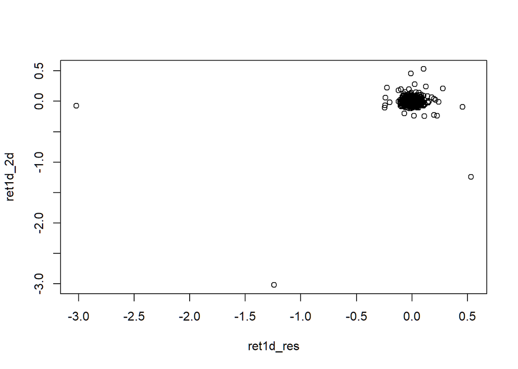

```r
plot(ret1d_res, ret1d_2d)
```

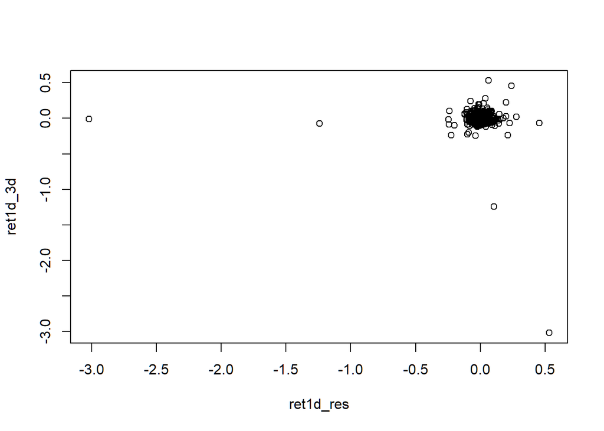

```r
plot(ret1d_res, ret1d_3d)
```

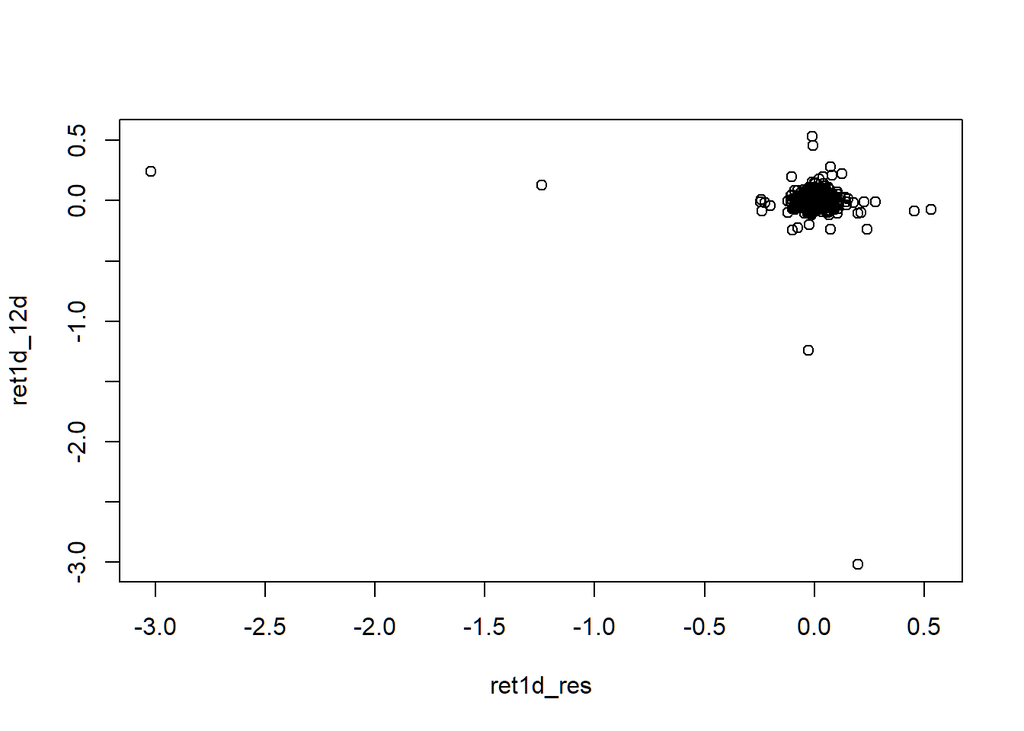

```r
plot(ret1d_res, ret1d_12d)
```

We can sense there are problem due to outliers in the plots. Let’s continue first.

## Test Performance

```r
# Making sure prediction has the same length as actual
assert(length(ret1d_pred) == length(ret1d_res))

oil_daily_ret_trunc <- filter(oil_daily_ret, n() - row_number() >= max(acf_index)-1)
assert(nrow(oil_daily_ret_trunc) == length(ret1d_res))

oil_daily_ret_trunc['ret_pred'] <- ret1d_pred
oil_daily_ret_trunc
```

| Date | Value | ret | ret_pred |
| --- | --- | --- | --- |
| 2020-10-05 | 39.12 | 6.016260e-02 | -5.753500e-03 |
| 2020-10-02 | 36.90 | -4.180732e-02 | -1.694794e-02 |
| 2020-10-01 | 38.51 | -3.845194e-02 | 7.411787e-03 |
| 2020-09-30 | 40.05 | 2.613374e-02 | -1.437722e-02 |
| 2020-09-29 | 39.03 | -3.558191e-02 | 2.495792e-03 |
| 2020-09-28 | 40.47 | 1.023465e-02 | -1.959109e-03 |
| 2020-09-25 | 40.06 | -1.246572e-03 | 1.047858e-03 |
| 2020-09-24 | 40.11 | 4.759519e-03 | -2.358933e-03 |
| 2020-09-23 | 39.92 | 9.355247e-03 | 1.508745e-02 |
| 2020-09-22 | 39.55 | 7.386653e-03 | -9.011747e-03 |

[output cut: 3689 more lines]

### Predication correctness

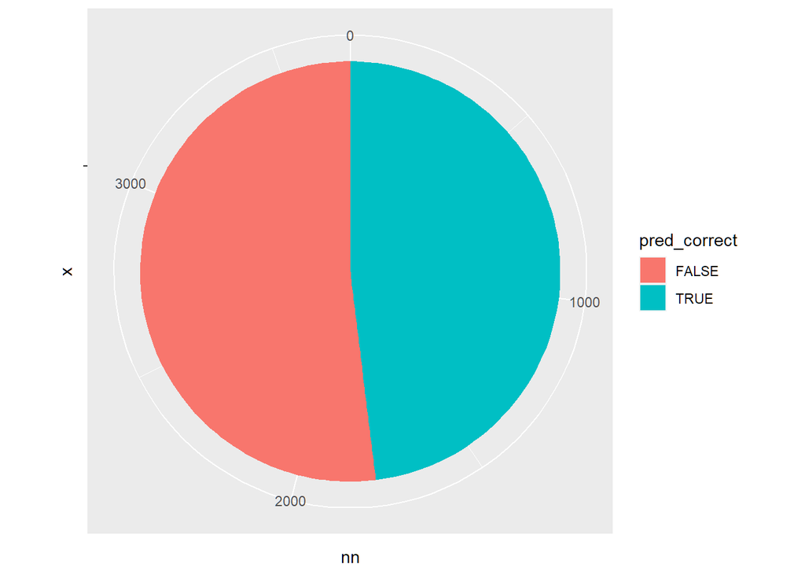

```r
oil_daily_ret_trunc['pred_correct'] <- oil_daily_ret_trunc['ret_pred'] * oil_daily_ret_trunc['ret'] > 0

oil_daily_ret_trunc %>% group_by(pred_correct) %>% summarise(nn = n()) %>% ungroup() %>%
  { ggplot(.) + geom_bar(aes(x='',y = nn, fill = pred_correct), stat='identity') + coord_polar("y", start=0) }
```

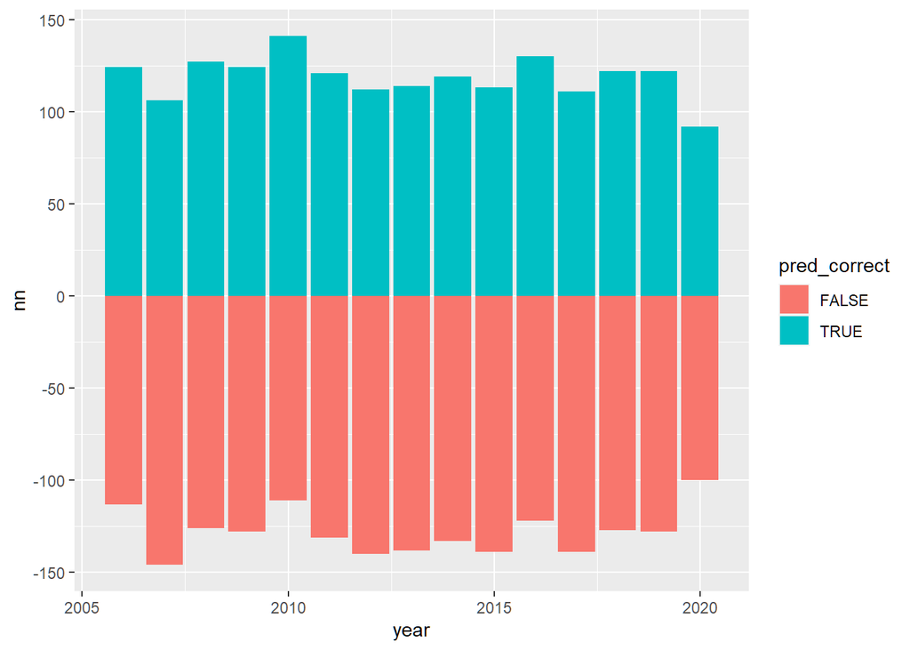

```r
oil_daily_ret_trunc %>% group_by(year = year(Date),pred_correct) %>% summarise(nn = n()) %>% ungroup() %>%
  mutate(nn = if_else(pred_correct, nn, -nn)) %>% ggplot(.) +
  geom_bar(aes(x = year, y = nn, fill = pred_correct), stat = "identity")
```

### Trading return

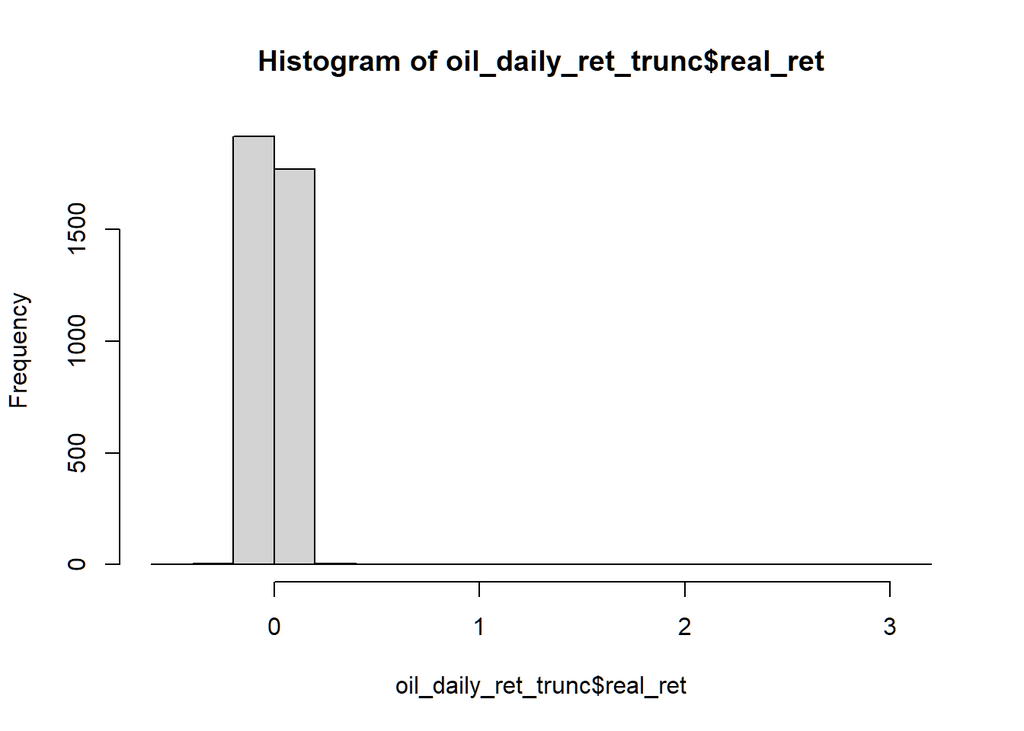

```r
oil_daily_ret_trunc['real_ret'] <- if_else(oil_daily_ret_trunc['ret_pred'] > 0, 1, -1) * oil_daily_ret_trunc['ret']

hist(oil_daily_ret_trunc$real_ret)
```

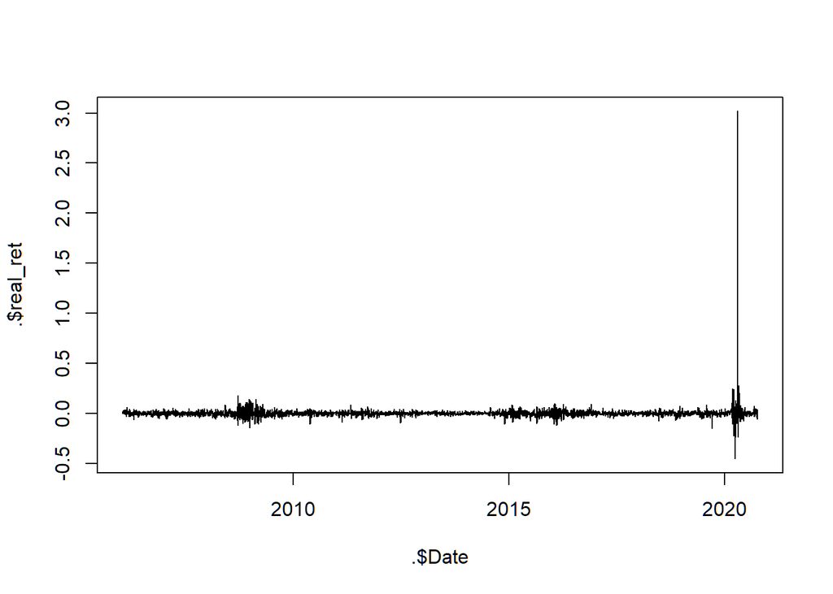

```r
oil_daily_ret_trunc %>% { plot(.$Date, .$real_ret, type = 'l') }
```

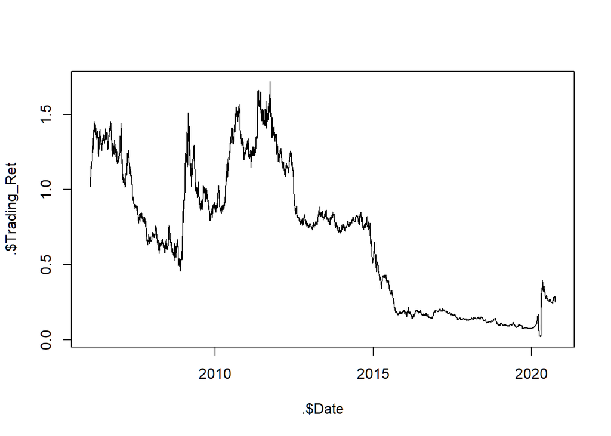

```r
arrange(oil_daily_ret_trunc, Date) %>% mutate(Trading_Ret = cumprod(1 + real_ret)) %>% { plot(.$Date, .$Trading_Ret, type = 'l') }
```

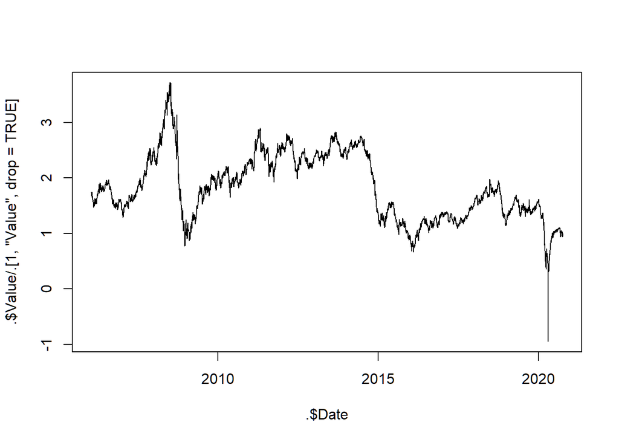

```r
oil_daily_ret_trunc %>% { plot(.$Date, .$Value / .[1,'Value',drop=TRUE], type = 'l') }
```

## We shall readdress the problem of outliers

- It’s negative prices in Apr-20,

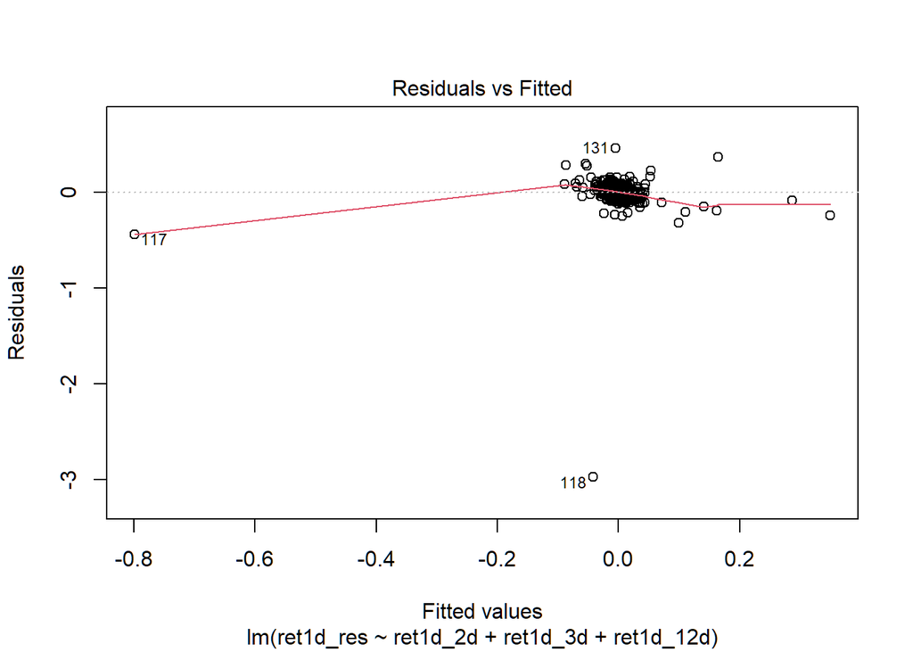

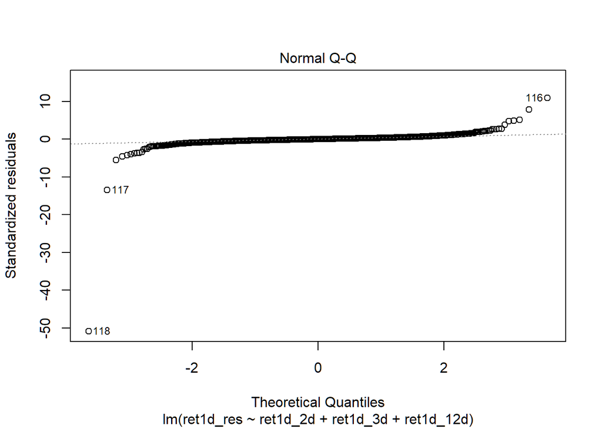

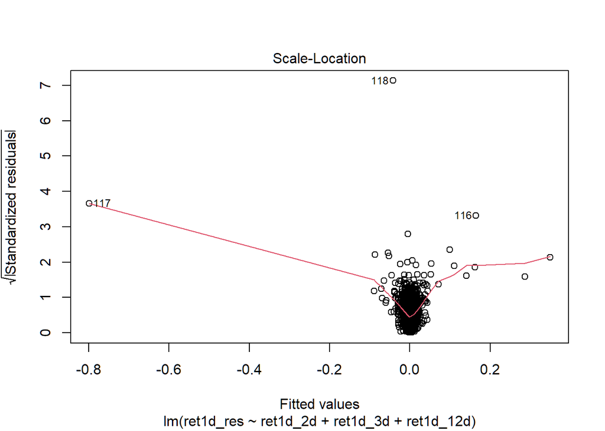

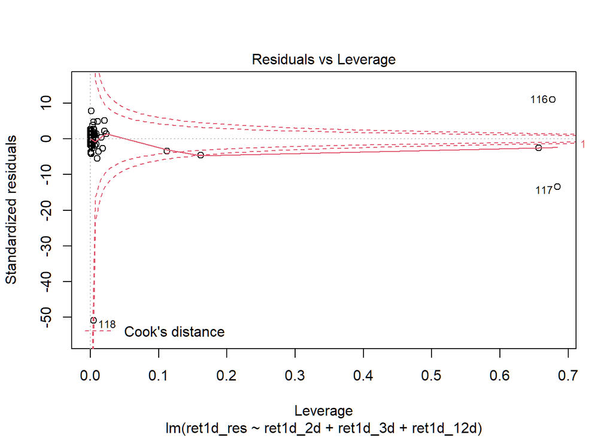

```r
plot(lm_res)
```

```r
oil_daily_original <- oil_daily
oil_daily_original %>% filter(Value < 0)
```

| Date | Value |
| --- | --- |
| 2020-04-20 | -36.98 |

### Restart and let’s get organized now

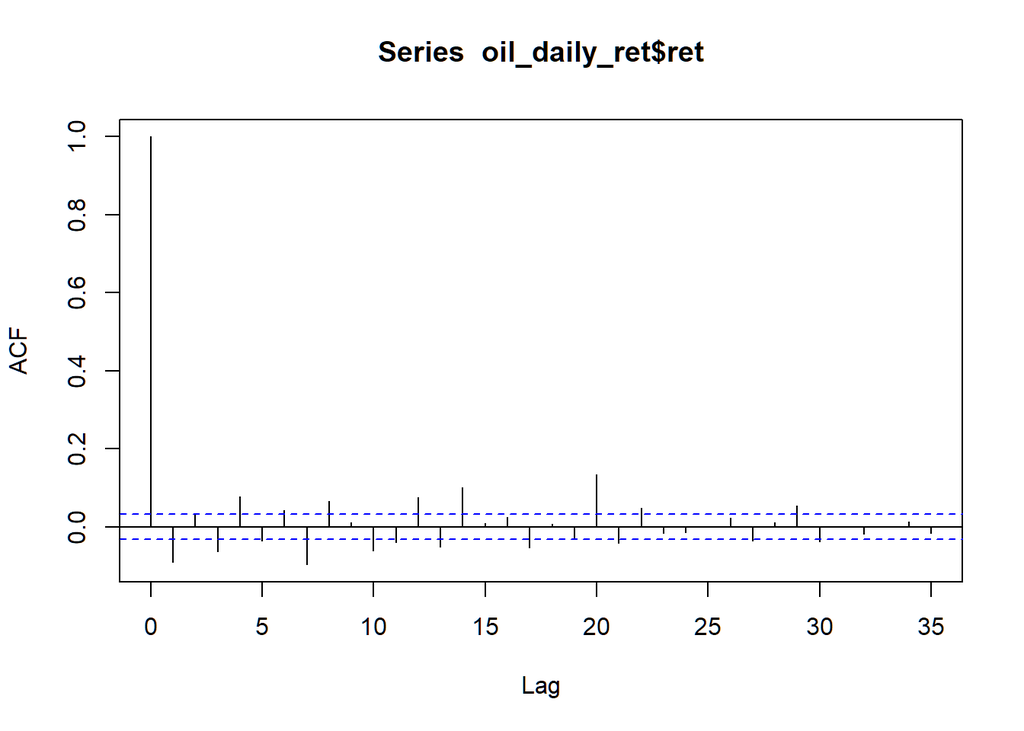

```r
oil_daily <- oil_daily_original %>% filter(Value > 0)
oil_daily_ret <- oil_daily %>% mutate(ret = Value / lead(Value, 1) - 1 ) %>% head(-1)
acf_result <- acf(oil_daily_ret$ret)
```

```r
acf_v <- acf_result$acf
acf_vv <- cbind(acf_v, 1:length(acf_v), abs(acf_v))
# pick the top 3
acf_index <- acf_vv[order(acf_vv[,3], decreasing = TRUE),][2:4,2]
acf_index
```

```
## [1] 21 15  8
```

```r
ret1d <- oil_daily_ret$ret
ret1d_res <- ret_lag(ret1d, max(acf_index), 1)
ret1d_t1 <- ret_lag(ret1d, max(acf_index), acf_index[1])
ret1d_t2 <- ret_lag(ret1d, max(acf_index), acf_index[2])
ret1d_t3 <- ret_lag(ret1d, max(acf_index), acf_index[3])
# We have earlier tested the code to be implemented correctedly so we can just use them.

lm_res <- lm(ret1d_res ~ ret1d_t1 + ret1d_t2 + ret1d_t3)
summary(lm_res)
```

```
##
## Call:
## lm(formula = ret1d_res ~ ret1d_t1 + ret1d_t2 + ret1d_t3)
##
## Residuals:
##      Min       1Q   Median       3Q      Max
## -0.47274 -0.01257  0.00023  0.01216  0.45915
##
## Coefficients:
##               Estimate Std. Error t value Pr(>|t|)
## (Intercept)  0.0002930  0.0005018   0.584    0.559
## ret1d_t1     0.1259913  0.0162669   7.745 1.22e-14 ***
## ret1d_t2     0.0874275  0.0163048   5.362 8.73e-08 ***
## ret1d_t3    -0.0817566  0.0163065  -5.014 5.59e-07 ***
## ---
## Signif. codes:  0 '***' 0.001 '**' 0.01 '*' 0.05 '.' 0.1 ' ' 1
##
## Residual standard error: 0.03047 on 3685 degrees of freedom
## Multiple R-squared:  0.03351,    Adjusted R-squared:  0.03272
## F-statistic: 42.59 on 3 and 3685 DF,  p-value: < 2.2e-16
```

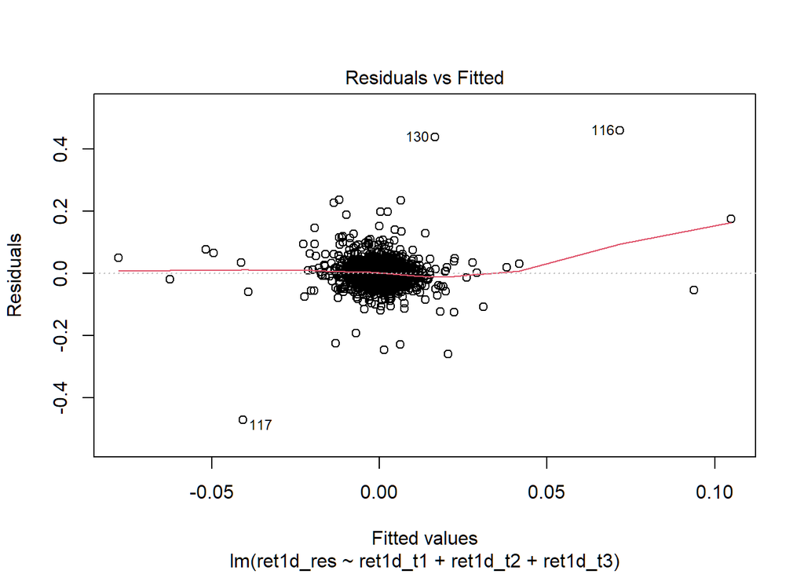

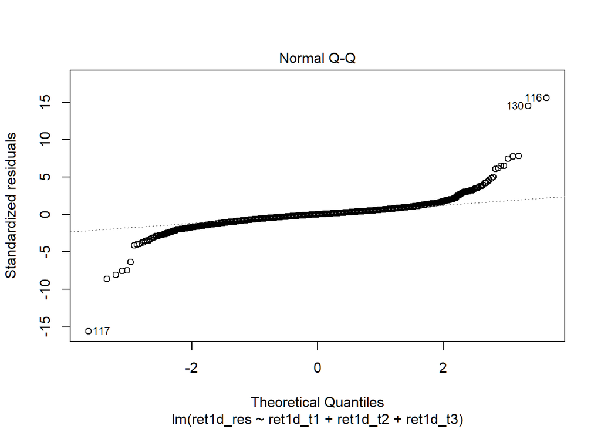

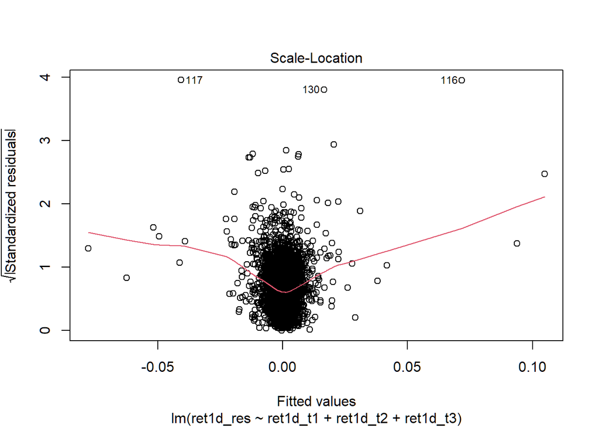

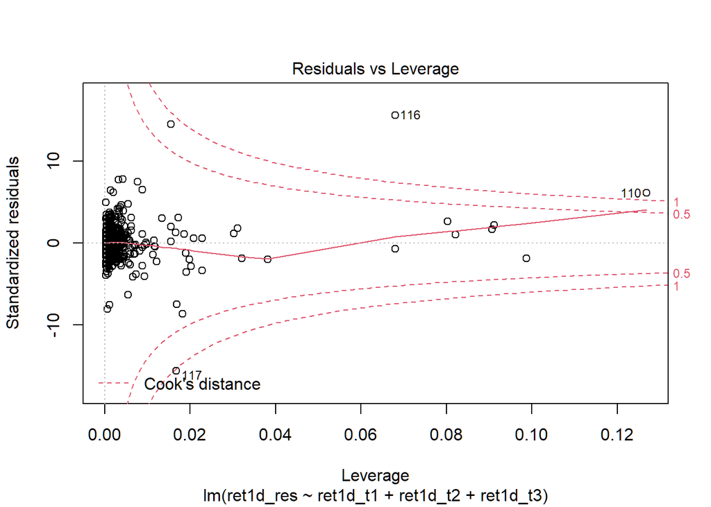

```r
plot(lm_res)
```

```r
ret1d_pred <- cbind(1, ret1d_t1, ret1d_t2, ret1d_t3) %*% as.matrix(lm_res$coefficients)

oil_daily_ret_trunc <- filter(oil_daily_ret, n() - row_number() >= max(acf_index)-1)
assert(nrow(oil_daily_ret_trunc) == length(ret1d_res))
oil_daily_ret_trunc['ret_pred'] <- ret1d_pred
```

### Predication correctness

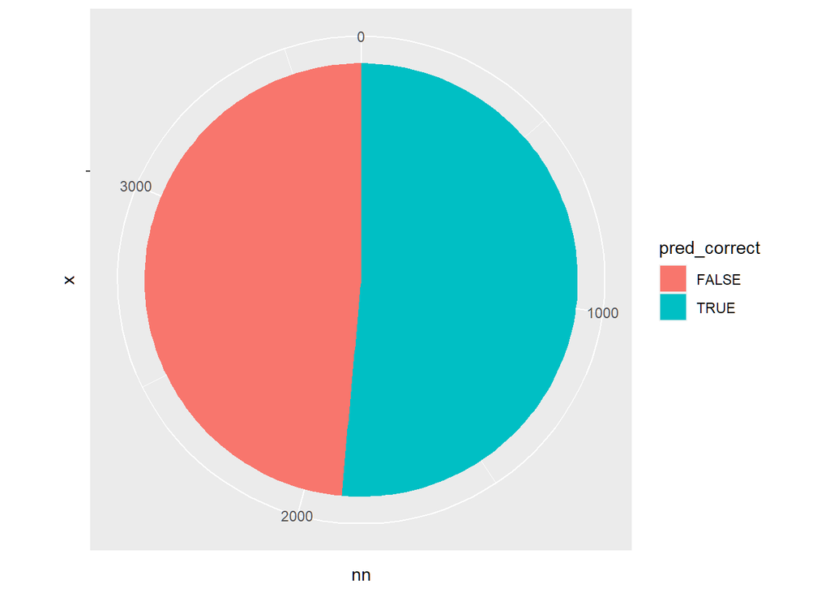

```r
oil_daily_ret_trunc['pred_correct'] <- oil_daily_ret_trunc['ret_pred'] * oil_daily_ret_trunc['ret'] > 0

oil_daily_ret_trunc %>% group_by(pred_correct) %>% summarise(nn = n()) %>% ungroup() %>%
  { ggplot(.) + geom_bar(aes(x='',y = nn, fill = pred_correct), stat='identity') + coord_polar("y", start=0) }
```

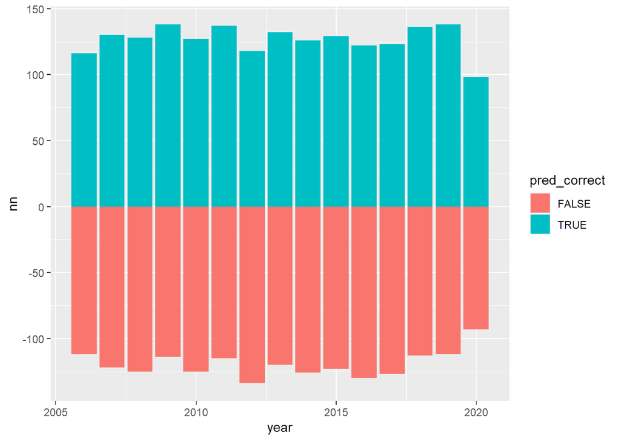

```r
oil_daily_ret_trunc %>% group_by(year = year(Date),pred_correct) %>% summarise(nn = n()) %>% ungroup() %>%
  mutate(nn = if_else(pred_correct, nn, -nn)) %>% ggplot(.) +
  geom_bar(aes(x = year, y = nn, fill = pred_correct), stat = "identity")
```

### Trading return

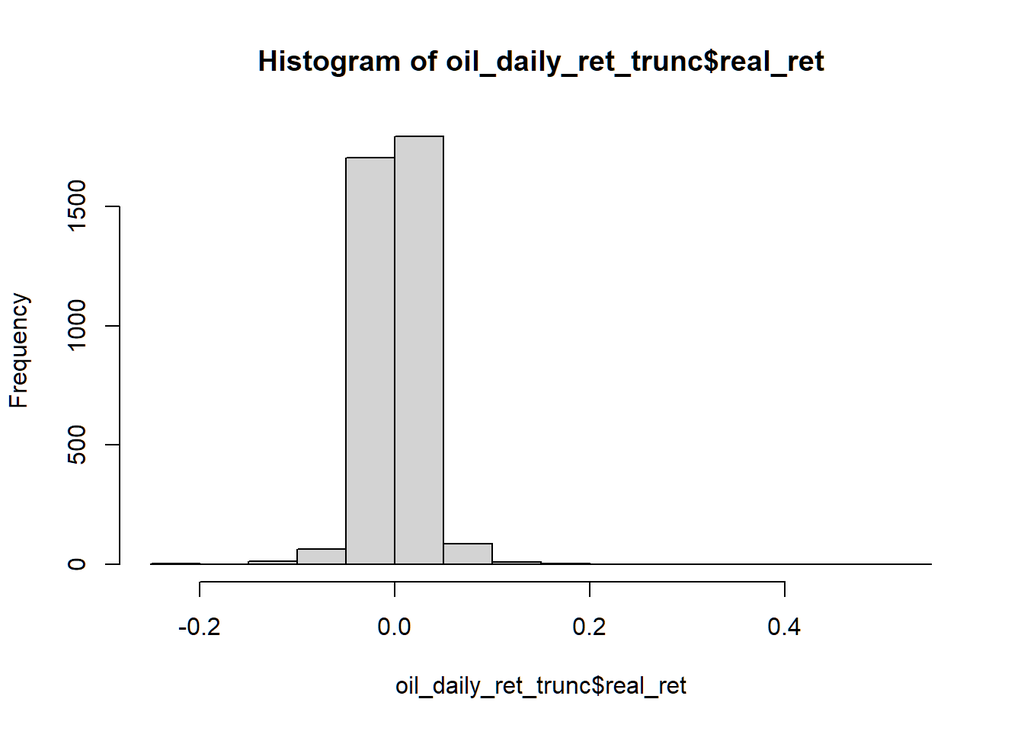

```r
# Just one line, but this calculates the PnL.
oil_daily_ret_trunc['real_ret'] <- if_else(oil_daily_ret_trunc['ret_pred'] > 0, 1, -1) * oil_daily_ret_trunc['ret']

hist(oil_daily_ret_trunc$real_ret)
```

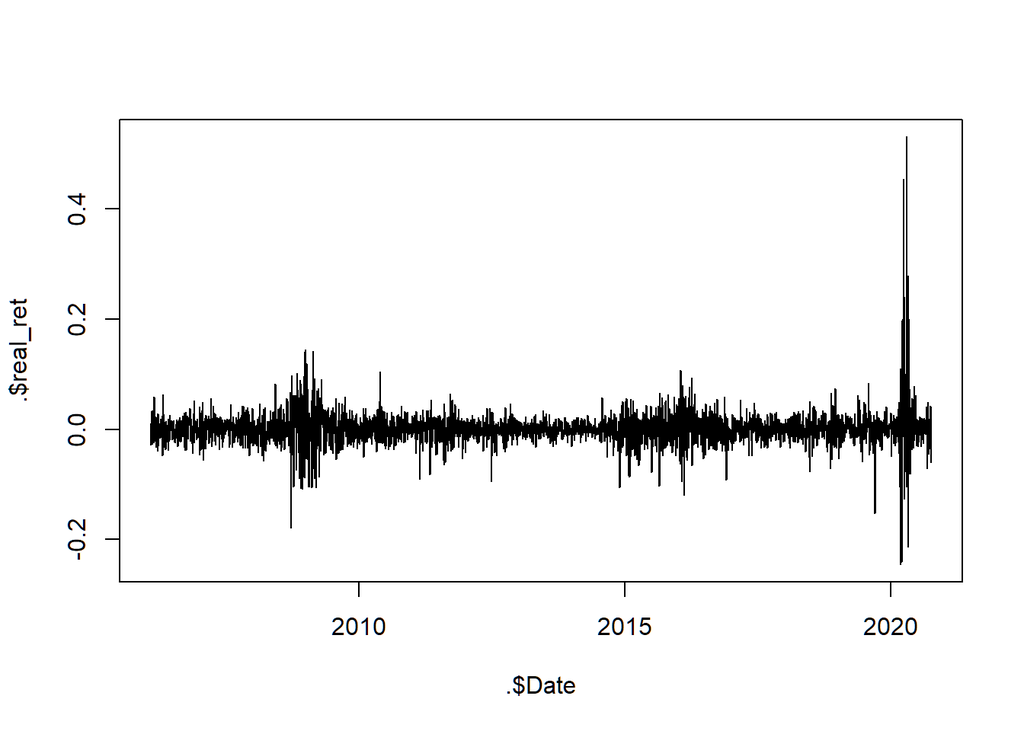

```r
oil_daily_ret_trunc %>% { plot(.$Date, .$real_ret, type = 'l') }
```

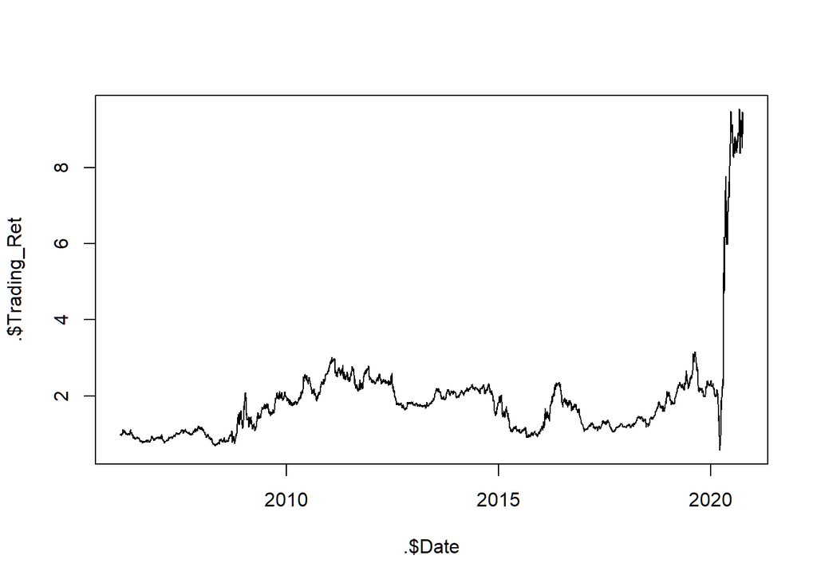

```r
arrange(oil_daily_ret_trunc, Date) %>% mutate(Trading_Ret = cumprod(1 + real_ret)) %>% { plot(.$Date, .$Trading_Ret, type = 'l') }
```

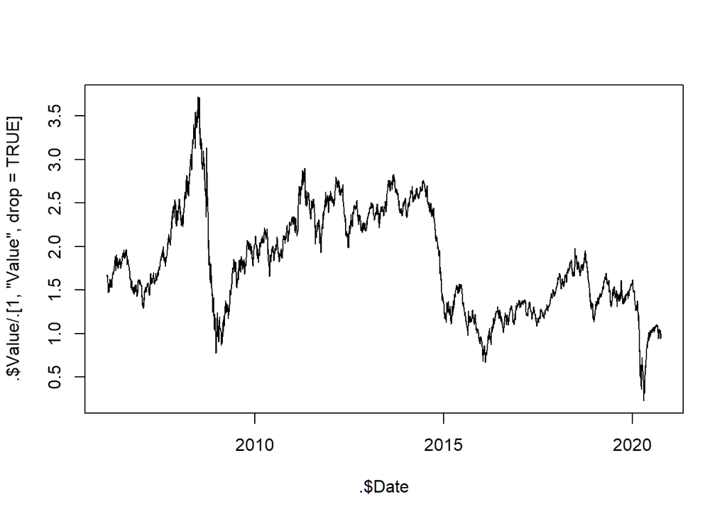

```r
oil_daily_ret_trunc %>% { plot(.$Date, .$Value / .[1,'Value',drop=TRUE], type = 'l') }
```

## To verify everything

- Clean the environment and run again.
- Move the code from notebook to R script file

## Take-Home

- The actual quant work takes small steps to build something
  - Exploratory data analysis and observation
  - Data filtering/cleaning
  - Modeling: I must state here that output from model was not clearly examined, like p-value and residual error. We use as is to figure out the relationship between output and dependents.
  - Running: Often, we need to repeat the whole thing from beginning.
  - Check the code repeatedly
- Therefore, programming practice/habit is important
  - Use simple code first, later refine for better visualization.
  - Add header/comments to organize the code
  - Add many assertion point so as to remember and test the assumptions.
  - Write functions, reduce code copying to the minimal.
  - Try to write the code when need to do things again, when moving the code (the main logic) from notebook to script files.